# Taller 02 puntos 1, 2, 5 y 6

2025-05-03

## Instalar las librerías necesarias

```r
#install.packages("plotly")
#install.packages("MASS")
#install.packages("psych")
#install.packages("tidyverse")
#install.packages("factoextra")
#install.packages("GGally")
#install.packages("corrplot")
#install.packages("psych")
#install.packages("writexl")
#install.packages("GGally")

library(GGally)
library(writexl)
library(plotly)
library(MASS)
library(psych)
library(tidyverse)
library(factoextra)
library(FactoMineR)
library(GGally)
library(corrplot)
library(psych)
library(ggplot2)
```

## Importar el dataset

```r
datos_taller_02 <- read.csv("/cloud/project/datos_taller_02.csv", header=TRUE, sep=";")
```

## Punto 1

Encuentre la estimación del vector de medias y la matriz de varianzas y covarianzas para 5 variables de su interés del conjunto de datos.

### Vector de Medias

```r
# Seleccionar las 5 variables de interés
vars_interes <- datos_taller_02[, c(12, 16, 17, 40, 58)]

# Estimación del vector de medias
vector_medias <- colMeans(vars_interes)
print(vector_medias)
```

```
##                    Kerosene_consumption_TBPD
##                                     8.224625
##              Motor_gasoline_consumption_TBPD
##                                   214.132432
##               Motor_gasoline_production_TBPD
##                                   211.467568
## Fossil_fuels_electricity_net_generation_BKWH
##                                   132.584084
##         Wind_electricity_net_generation_BKWH
##                                     6.084685
```

Unidades en las que se miden las variables a estudiar: - TBPD (Thousand Barrels Per Day) - BKWH (Billion Kilowatt-hours)

Se observa que el promedio de consumo de gasolina es muy alto en comparación con otras variables, y que la generación eólica todavía es baja en promedio.

### Matriz de varianzas y covarianzas

```r
# Estimación de la matriz de varianzas y covarianzas
matriz_covarianzas <- cov(vars_interes)
print(matriz_covarianzas)
```

```
##                                              Kerosene_consumption_TBPD
## Kerosene_consumption_TBPD                                   1111.20579
## Motor_gasoline_consumption_TBPD                             3652.59338
## Motor_gasoline_production_TBPD                              4047.14314
## Fossil_fuels_electricity_net_generation_BKWH                4495.08919
## Wind_electricity_net_generation_BKWH                          91.56329
##                                              Motor_gasoline_consumption_TBPD
## Kerosene_consumption_TBPD                                           3652.593
## Motor_gasoline_consumption_TBPD                                   790595.046
## Motor_gasoline_production_TBPD                                    834206.418
## Fossil_fuels_electricity_net_generation_BKWH                      318100.939
## Wind_electricity_net_generation_BKWH                               18042.266
##                                              Motor_gasoline_production_TBPD
## Kerosene_consumption_TBPD                                          4047.143
## Motor_gasoline_consumption_TBPD                                  834206.418
## Motor_gasoline_production_TBPD                                   890035.397
## Fossil_fuels_electricity_net_generation_BKWH                     335168.583
## Wind_electricity_net_generation_BKWH                              19190.037
##                                              Fossil_fuels_electricity_net_generation_BKWH
## Kerosene_consumption_TBPD                                                        4495.089
## Motor_gasoline_consumption_TBPD                                                318100.939
## Motor_gasoline_production_TBPD                                                 335168.583
## Fossil_fuels_electricity_net_generation_BKWH                                   223824.714
## Wind_electricity_net_generation_BKWH                                            10183.494
##                                              Wind_electricity_net_generation_BKWH
## Kerosene_consumption_TBPD                                                91.56329
## Motor_gasoline_consumption_TBPD                                       18042.26614
## Motor_gasoline_production_TBPD                                        19190.03732
## Fossil_fuels_electricity_net_generation_BKWH                          10183.49430
## Wind_electricity_net_generation_BKWH                                    563.17167
```

Las covarianzas (situadas fuera de la diagonal de la matriz) indican cómo dos variables interactuan. Los valores positivos indican relación directa o positiva, los valores negativos indican una relación indirecta o negativa, es decir, mientra una aumenta la otra disminuye. Y por último, si el valor es cero o cercano a cero, indica que las variables no tienen relación.

A continuación, se muestra la diagonal de la matriz de varianzas y covarianzas, que representan la varianza de cada variable, es decir, qué tanto se dispersan los datos respecto a su media.

```r
# Varianza de cada una de las variables
print (diag(matriz_covarianzas))
```

```
##                    Kerosene_consumption_TBPD
##                                    1111.2058
##              Motor_gasoline_consumption_TBPD
##                                  790595.0460
##               Motor_gasoline_production_TBPD
##                                  890035.3975
## Fossil_fuels_electricity_net_generation_BKWH
##                                  223824.7141
##         Wind_electricity_net_generation_BKWH
##                                     563.1717
```

- La producción y consumo de gasolina tienen altísima varianza, lo que sugiere grandes diferencias entre países.
- La generación eólica tiene baja varianza, lo que indica que la mayoría de los países tienen valores similares (probablemente bajos).
- La generación eléctrica por fósiles también muestra alta varianza, lo cual refleja diferencias estructurales entre países en sus sistemas eléctricos.

## PUNTO 2

Realice un análisis descriptivo univariado y bivariado del conjunto de datos. Considere nuevamente las mismas 5 variables de su interés para este punto.

### Análisis univariado

Resumen estadístico

```r
summary(vars_interes)
```

```
##  Kerosene_consumption_TBPD Motor_gasoline_consumption_TBPD
##  Min.   :  0.000           Min.   :   0.8
##  1st Qu.:  0.000           1st Qu.:  13.0
##  Median :  0.500           Median :  33.0
##  Mean   :  8.225           Mean   : 214.1
##  3rd Qu.:  2.300           3rd Qu.: 108.5
##  Max.   :298.000           Max.   :8921.0
##  Motor_gasoline_production_TBPD Fossil_fuels_electricity_net_generation_BKWH
##  Min.   :   0.0                 Min.   :   0.00
##  1st Qu.:   5.6                 1st Qu.:   4.25
##  Median :  37.0                 Median :  21.00
##  Mean   : 211.5                 Mean   : 132.58
##  3rd Qu.: 106.5                 3rd Qu.:  80.00
##  Max.   :9571.0                 Max.   :3985.00
##  Wind_electricity_net_generation_BKWH
##  Min.   :  0.000
##  1st Qu.:  0.000
##  Median :  0.100
##  Mean   :  6.085
##  3rd Qu.:  1.450
##  Max.   :182.000
```

Desviación estándar para cada variable

```r
sapply(vars_interes, sd, na.rm = TRUE)
```

```
##                    Kerosene_consumption_TBPD
##                                     33.33475
##              Motor_gasoline_consumption_TBPD
##                                    889.15412
##               Motor_gasoline_production_TBPD
##                                    943.41687
## Fossil_fuels_electricity_net_generation_BKWH
##                                    473.10117
##         Wind_electricity_net_generation_BKWH
##                                     23.73124
```

#### Histograma de distribución para cada variable

Histograma de distribución Kerosene_consumption_TBPD

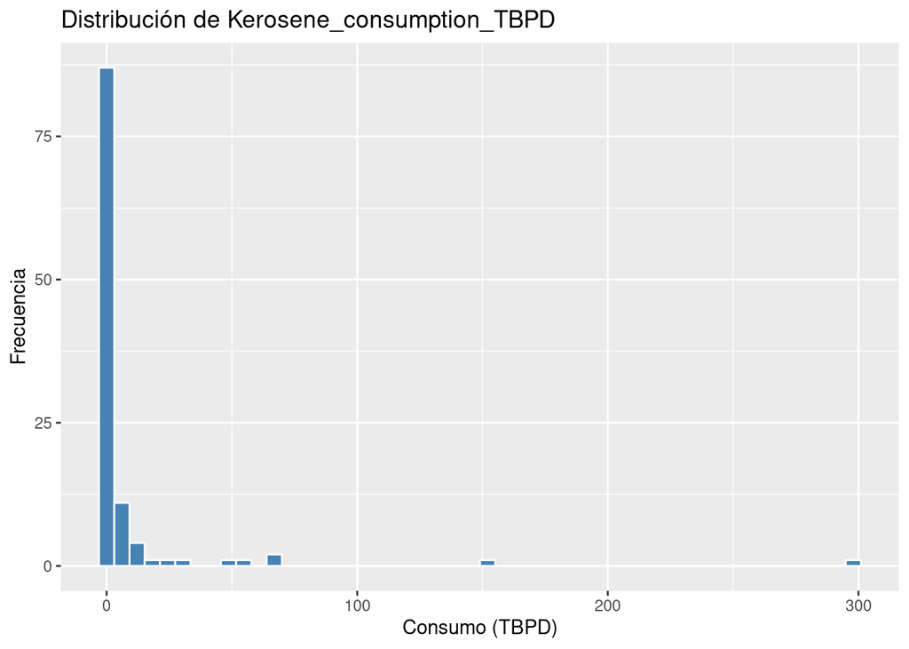

```r
ggplot(vars_interes, aes(x = Kerosene_consumption_TBPD)) +
  geom_histogram(fill = "steelblue", color = "white", bins = 50) +
  labs(title = "Distribución de Kerosene_consumption_TBPD",
       x = "Consumo (TBPD)",
       y = "Frecuencia")
```

Histograma de distribución Motor_gasoline_consumption_TBPD

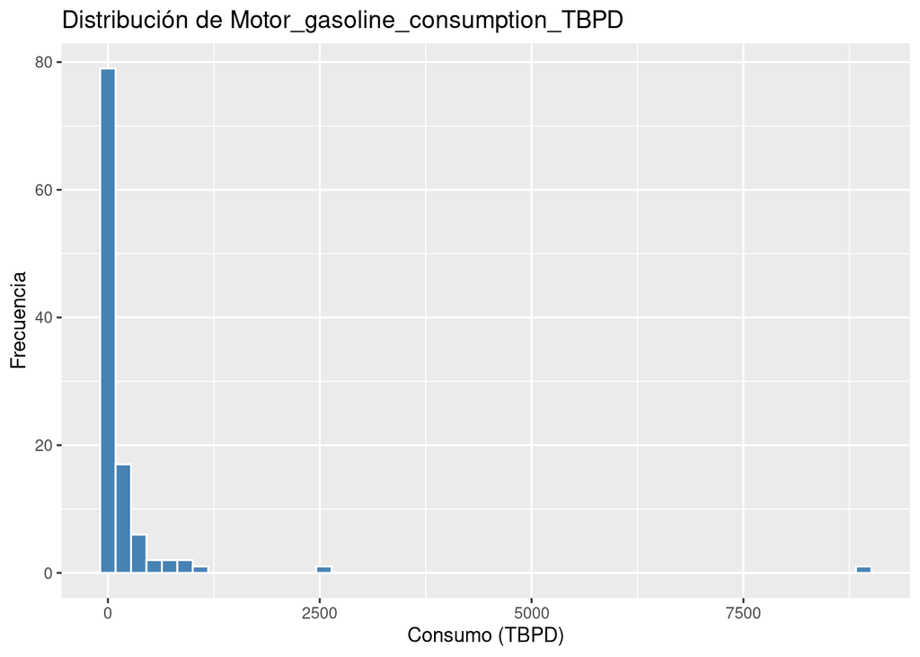

```r
ggplot(vars_interes, aes(x = Motor_gasoline_consumption_TBPD)) +
  geom_histogram(fill = "steelblue", color = "white", bins = 50) +
  labs(title = "Distribución de Motor_gasoline_consumption_TBPD",
       x = "Consumo (TBPD)",
       y = "Frecuencia")
```

Histograma de distribución Motor_gasoline_production_TBPD

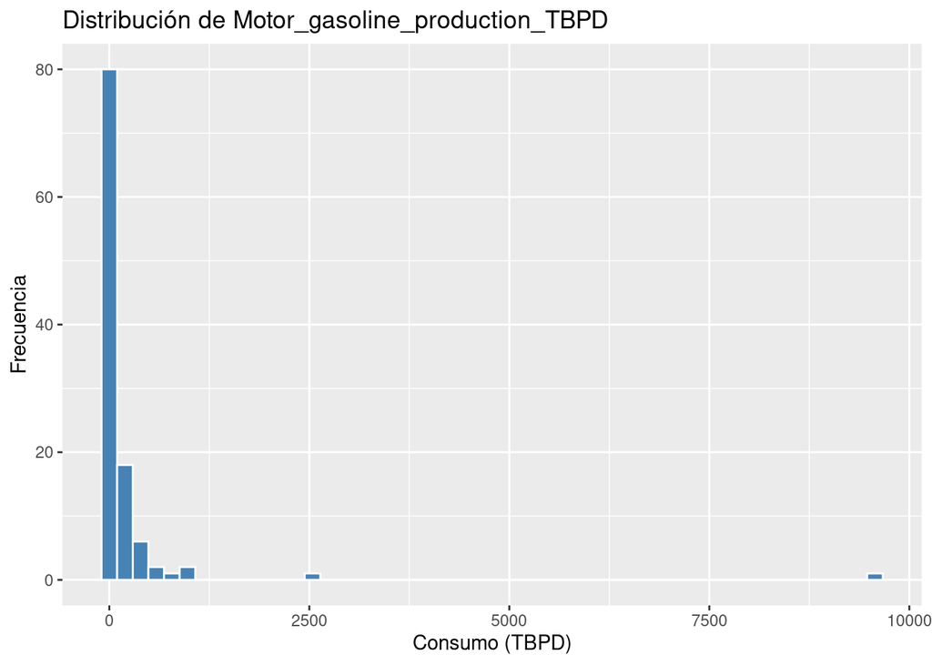

```r
ggplot(vars_interes, aes(x = Motor_gasoline_production_TBPD)) +
  geom_histogram(fill = "steelblue", color = "white", bins = 50) +
  labs(title = "Distribución de Motor_gasoline_production_TBPD",
       x = "Consumo (TBPD)",
       y = "Frecuencia")
```

Histograma de distribución Fossil_fuels_electricity_net_generation_BKWH

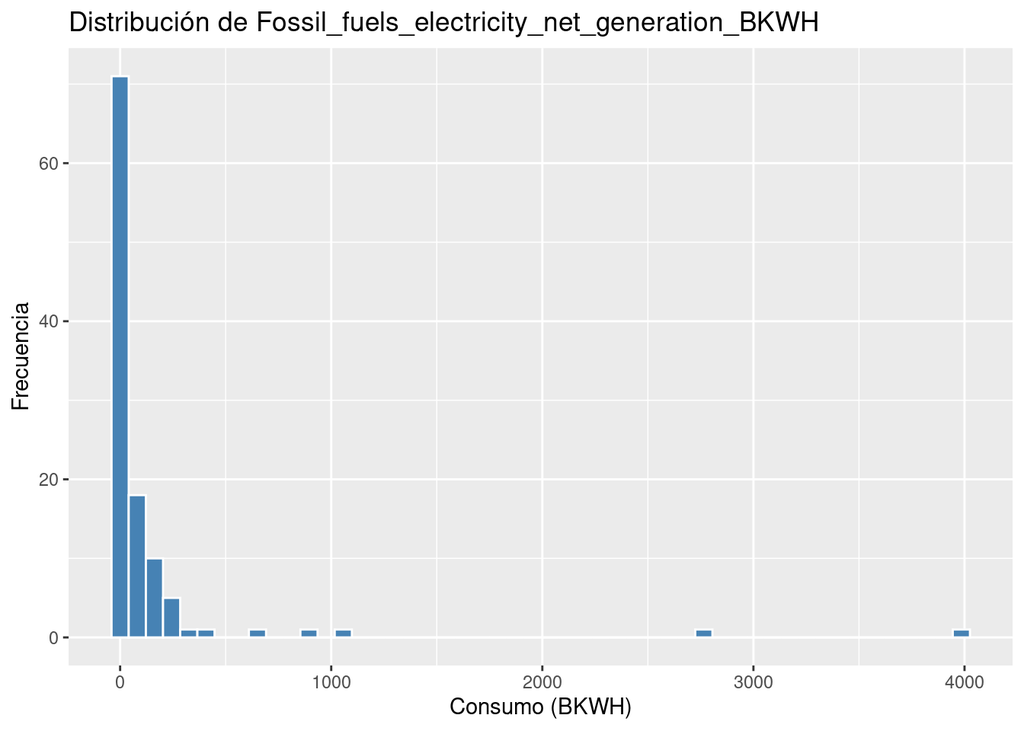

```r
ggplot(vars_interes, aes(x = Fossil_fuels_electricity_net_generation_BKWH)) +
  geom_histogram(fill = "steelblue", color = "white", bins = 50) +
  labs(title = "Distribución de Fossil_fuels_electricity_net_generation_BKWH",
       x = "Consumo (BKWH)",
       y = "Frecuencia")
```

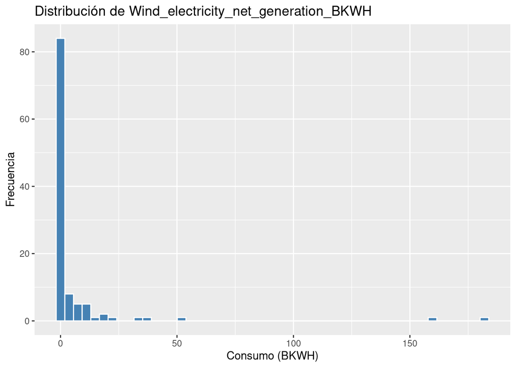

```r
ggplot(vars_interes, aes(x = Wind_electricity_net_generation_BKWH)) +
  geom_histogram(fill = "steelblue", color = "white", bins = 50) +
  labs(title = "Distribución de Wind_electricity_net_generation_BKWH",
       x = "Consumo (BKWH)",
       y = "Frecuencia")
```

#### Boxplots Boxplot Kerosene_consumption_TBPD

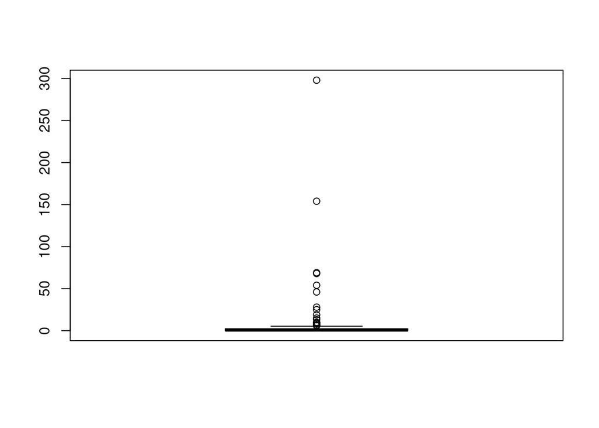

```r
boxplot(vars_interes$Kerosene_consumption_TBPD)
```

Boxplot Motor_gasoline_consumption_TBPD

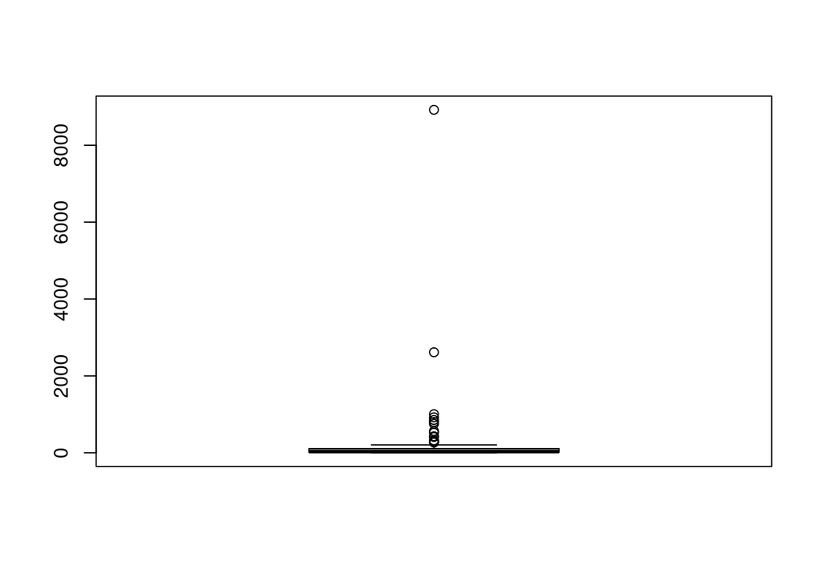

```r
boxplot(vars_interes$Motor_gasoline_consumption_TBPD)
```

Boxplot Motor_gasoline_production_TBPD

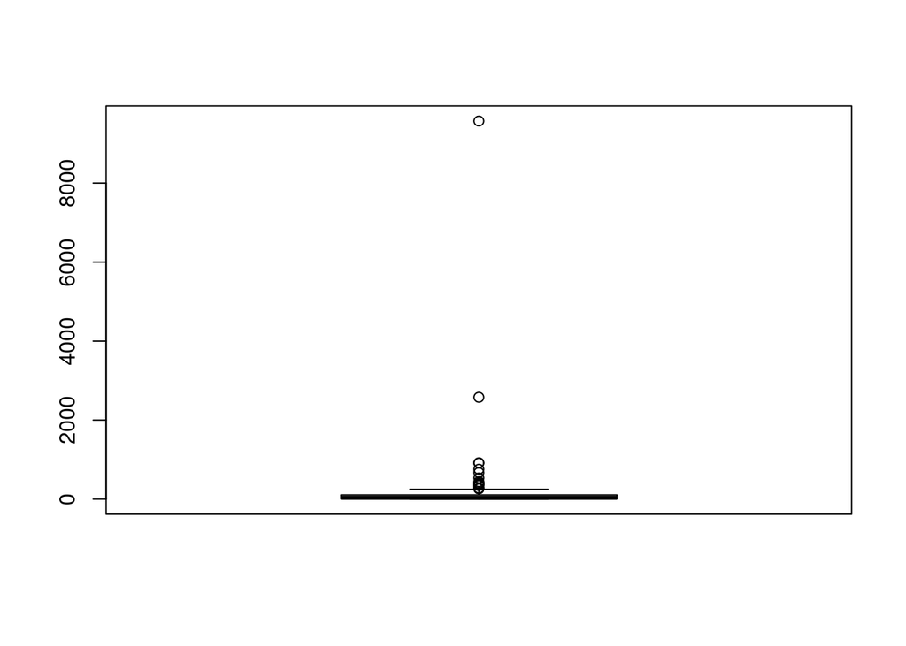

```r
boxplot(vars_interes$Motor_gasoline_production_TBPD)
```

Boxplot Fossil_fuels_electricity_net_generation_BKWH

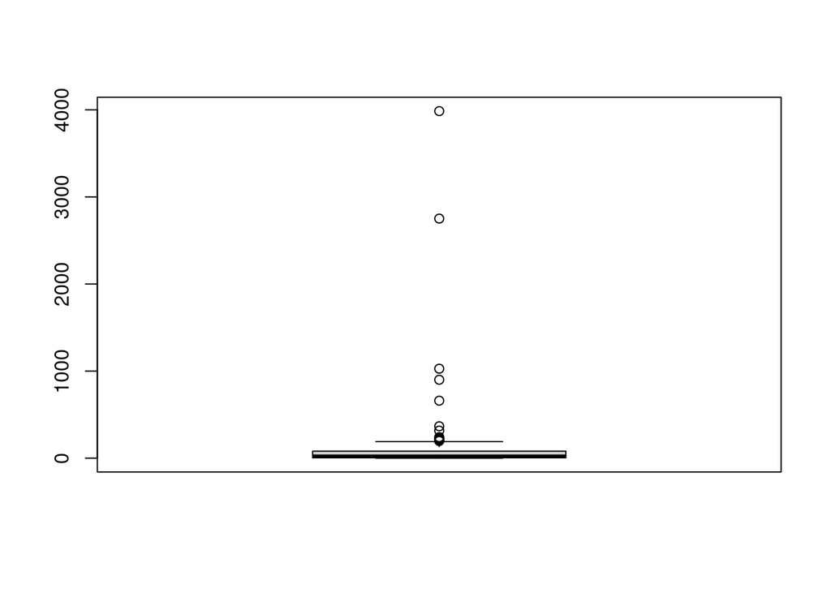

```r
boxplot(vars_interes$Fossil_fuels_electricity_net_generation_BKWH)
```

Boxplot Wind_electricity_net_generation_BKWH

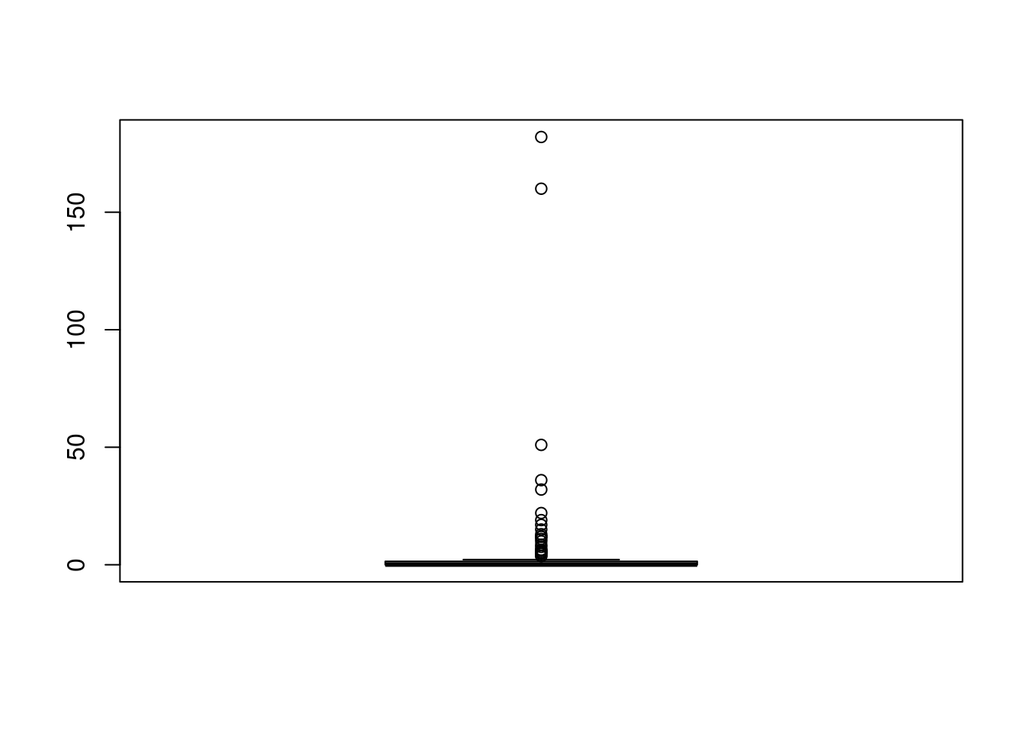

```r
boxplot(vars_interes$Wind_electricity_net_generation_BKWH)
```

### Análisis multivariado

La matriz de correlación indica la fuerza y dirección de las relaciones lineales entre las variables de un conjunto de datos.

```r
correlaciones <- cor(vars_interes, use = "complete.obs")
print(correlaciones)
```

```
##                                              Kerosene_consumption_TBPD
## Kerosene_consumption_TBPD                                    1.0000000
## Motor_gasoline_consumption_TBPD                              0.1232330
## Motor_gasoline_production_TBPD                               0.1286909
## Fossil_fuels_electricity_net_generation_BKWH                 0.2850277
## Wind_electricity_net_generation_BKWH                         0.1157454
##                                              Motor_gasoline_consumption_TBPD
## Kerosene_consumption_TBPD                                          0.1232330
## Motor_gasoline_consumption_TBPD                                    1.0000000
## Motor_gasoline_production_TBPD                                     0.9944726
## Fossil_fuels_electricity_net_generation_BKWH                       0.7561952
## Wind_electricity_net_generation_BKWH                               0.8550542
##                                              Motor_gasoline_production_TBPD
## Kerosene_consumption_TBPD                                         0.1286909
## Motor_gasoline_consumption_TBPD                                   0.9944726
## Motor_gasoline_production_TBPD                                    1.0000000
## Fossil_fuels_electricity_net_generation_BKWH                      0.7509407
## Wind_electricity_net_generation_BKWH                              0.8571400
##                                              Fossil_fuels_electricity_net_generation_BKWH
## Kerosene_consumption_TBPD                                                       0.2850277
## Motor_gasoline_consumption_TBPD                                                 0.7561952
## Motor_gasoline_production_TBPD                                                  0.7509407
## Fossil_fuels_electricity_net_generation_BKWH                                    1.0000000
## Wind_electricity_net_generation_BKWH                                            0.9070316
##                                              Wind_electricity_net_generation_BKWH
## Kerosene_consumption_TBPD                                               0.1157454
## Motor_gasoline_consumption_TBPD                                         0.8550542
## Motor_gasoline_production_TBPD                                          0.8571400
## Fossil_fuels_electricity_net_generation_BKWH                            0.9070316
## Wind_electricity_net_generation_BKWH                                    1.0000000
```

- Alta correlación entre Motor_gasoline_consumption_TBPD y Motor_gasoline_production_TBPD: 0.9945. Esto indica una relación casi perfecta. Los países que más gasolina producen también la consumen mucho.
- Alta correlación entre entre Fossil_fuels_electricity_net_generation_BKWH y Wind_electricity_net_generation_BKWH: 0.9070. Los países que generan más electricidad con fósiles también tienen alta generación eólica.
- Correlación fuerte entre Motor_gasoline_production_TBPD y Wind_electricity_net_generation_BKWH: 0.8571. Los paises con alta producción de gasolina, también tienen una alta generación neta de electricidad eólica.
- Kerosene_consumption_TBPD tiene correlaciones débiles con todas las demás (< 0.29).

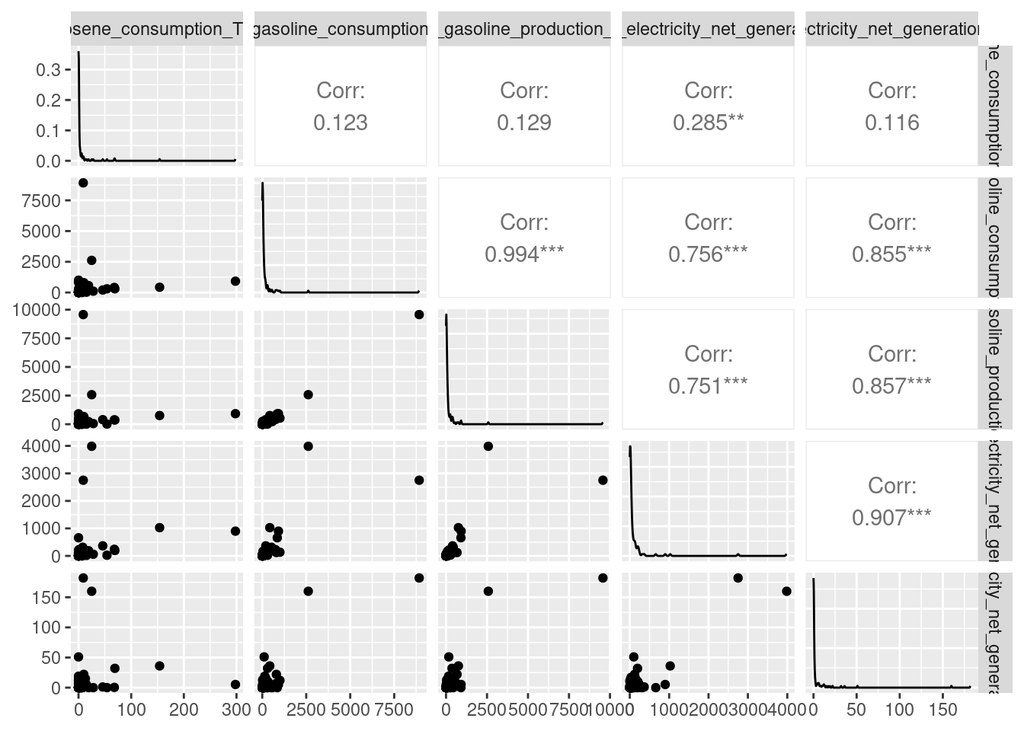

```r
ggpairs(vars_interes)
```

La mayoría de las variables tienen distribuciones sesgadas hacia valores bajos con algunos valores muy altos (ver diagramas de dispersión).

Esto sugiere que la mayoría de los países tienen baja producción o consumo, mientras que unos pocos tienen valores extremos.

## PUNTO 5

Analice la representación de las variables originales sobre las dos primeras componentes en el primer plano factorial. ¿Que conclusiones podemos sacar de este análisis?

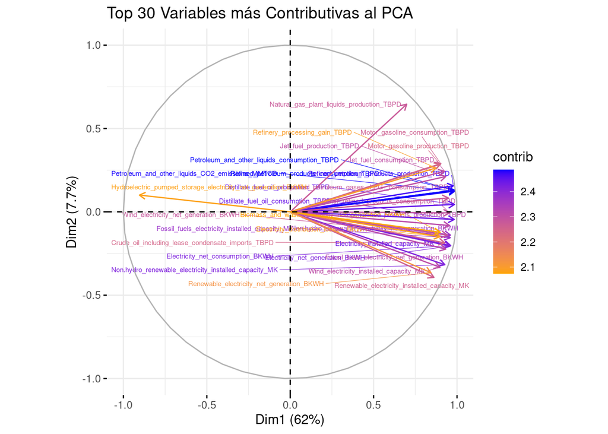

```r
datos <- subset(datos_taller_02, select = -Country )

# Ejecutar el PCA
res.pca <- PCA(datos, graph = FALSE)

# Visualizar las variables en el primer plano factorial
fviz_pca_var(res.pca,
             axes = c(1, 2),
             repel = TRUE,
             col.var = "contrib",
             gradient.cols = c("orange", "blue"),
             labelsize = 2,
             select.var = list(contrib = 30)) +  # 🔍 Selecciona las 10 variables más importantes
  ggtitle("Top 30 Variables más Contributivas al PCA")
```

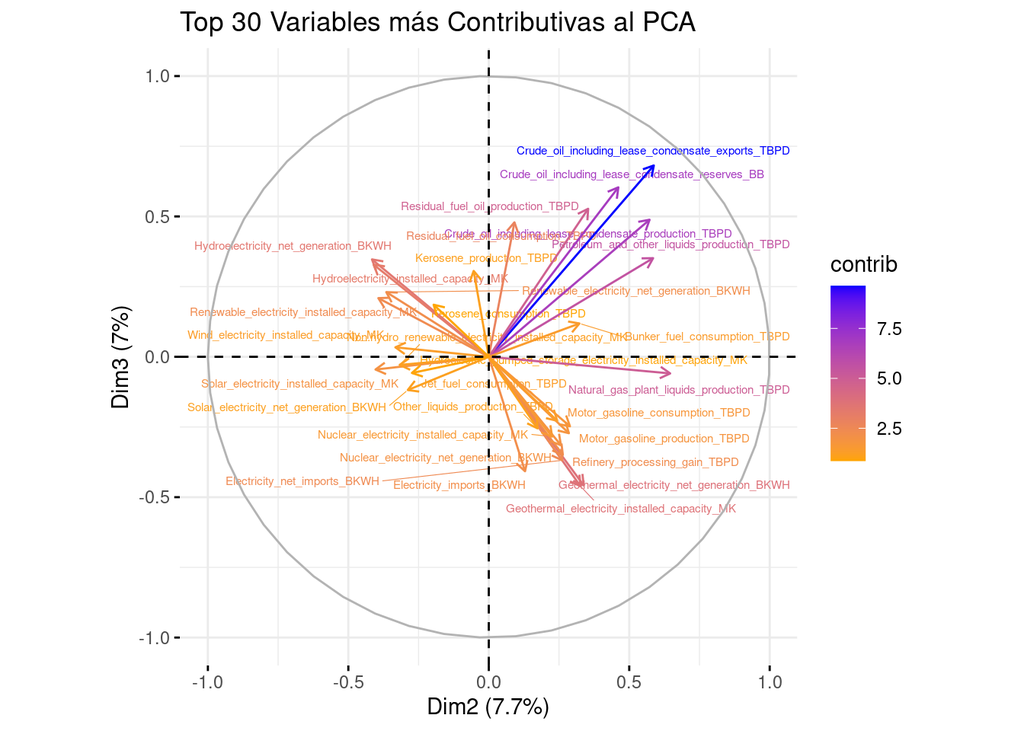

```r
# Visualizar las variables en el primer plano factorial
fviz_pca_var(res.pca,
             axes = c(2, 3),
             repel = TRUE,
             col.var = "contrib",
             gradient.cols = c("orange", "blue"),
             labelsize = 2,
             select.var = list(contrib = 30)) +  # 🔍 Selecciona las 10 variables más importantes
  ggtitle("Top 30 Variables más Contributivas al PCA")
```

## PUNTO 6

Ahora examine con detenimiento el mapa de individuos sobre los planos factoriales que conforman las componentes (1,2) y (2,3). ¿Qué conclusiones puede sacar según la cercanía de algunas UE?

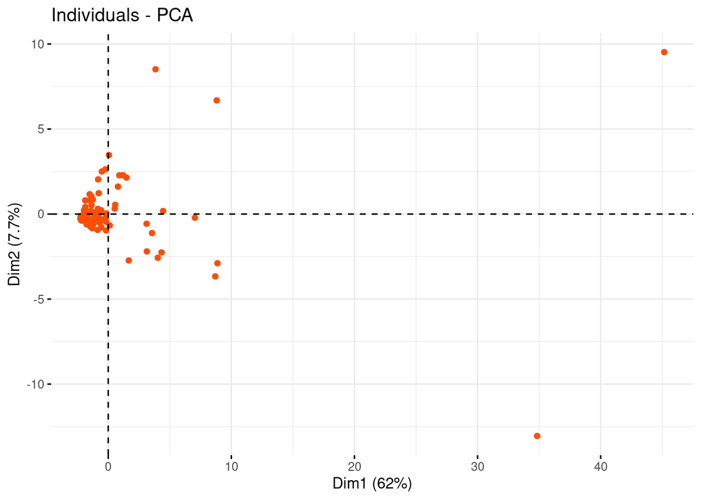

```r
fviz_pca_ind(res.pca, geom.ind = "point",
             col.ind = "#FC4E07",
             axes = c(1, 2),
             pointsize = 1.5)
```

Dim2 (7.7%):

- Su contribución parece marginal, por lo que el análisis se centra en Dim1 (62%).

Distribución de Países

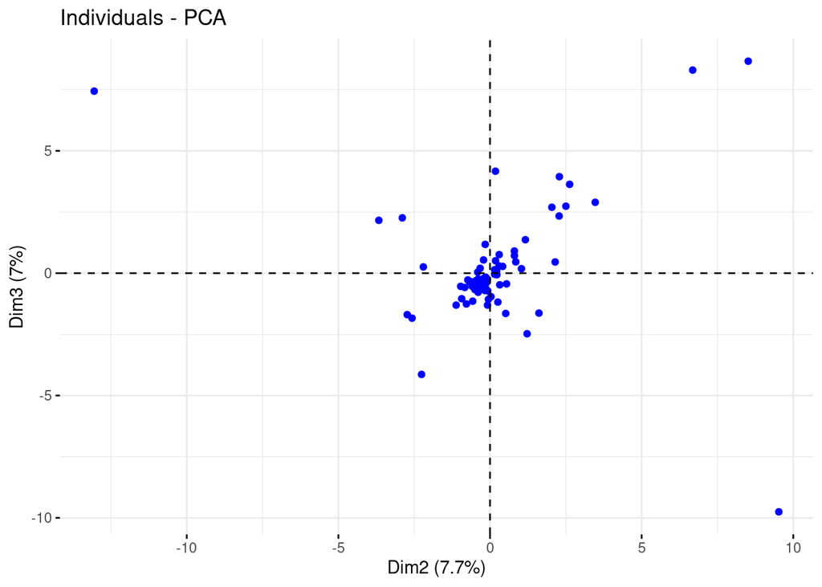

```r
fviz_pca_ind(res.pca, geom.ind = "point",
             col.ind = "blue",
             axes = c(2, 3),
             pointsize = 1.5)
```

Dim3 (7%) y Dim2 (7.7%):

Ambos componentes explican una proporción baja de varianza total (14.7% combinada). Esto sugiere que:

- La estructura subyacente de los datos es alta-dimensional (muchas variables influyentes no capturadas en estos ejes).